# HW 2

# Instructions :

# Problem 1: Fuzz Bizz

This is a program that prints the numbers from 1 to 1000, but with the following specific requirement:

- for multiples of three, print “Fuzz” instead of the number;
- for the multiples of five print “Bizz” instead of the number;
- for numbers which are multiples of both three and five print “FuzzBizz” instead of the number.

| 1 | 2 | Fuzz | 4 | Bizz | Fuzz | 7 | 8 | Fuzz | Bizz |
| --- | --- | --- | --- | --- | --- | --- | --- | --- | --- |
| 11 | Fuzz | 13 | 14 | FuzzBizz | 16 | 17 | Fuzz | 19 | Bizz |
| Fuzz | 22 | 23 | Fuzz | Bizz | 26 | Fuzz | 28 | 29 | FuzzBizz |
| 31 | 32 | Fuzz | 34 | Bizz | Fuzz | 37 | 38 | Fuzz | Bizz |
| 41 | Fuzz | 43 | 44 | FuzzBizz | 46 | 47 | Fuzz | 49 | Bizz |
| Fuzz | 52 | 53 | Fuzz | Bizz | 56 | Fuzz | 58 | 59 | FuzzBizz |
| 61 | 62 | Fuzz | 64 | Bizz | Fuzz | 67 | 68 | Fuzz | Bizz |
| 71 | Fuzz | 73 | 74 | FuzzBizz | 76 | 77 | Fuzz | 79 | Bizz |
| Fuzz | 82 | 83 | Fuzz | Bizz | 86 | Fuzz | 88 | 89 | FuzzBizz |
| 91 | 92 | Fuzz | 94 | Bizz | Fuzz | 97 | 98 | Fuzz | Bizz |
| 101 | Fuzz | 103 | 104 | FuzzBizz | 106 | 107 | Fuzz | 109 | Bizz |
| Fuzz | 112 | 113 | Fuzz | Bizz | 116 | Fuzz | 118 | 119 | FuzzBizz |
| 121 | 122 | Fuzz | 124 | Bizz | Fuzz | 127 | 128 | Fuzz | Bizz |
| 131 | Fuzz | 133 | 134 | FuzzBizz | 136 | 137 | Fuzz | 139 | Bizz |
| Fuzz | 142 | 143 | Fuzz | Bizz | 146 | Fuzz | 148 | 149 | FuzzBizz |
| 151 | 152 | Fuzz | 154 | Bizz | Fuzz | 157 | 158 | Fuzz | Bizz |
| 161 | Fuzz | 163 | 164 | FuzzBizz | 166 | 167 | Fuzz | 169 | Bizz |
| Fuzz | 172 | 173 | Fuzz | Bizz | 176 | Fuzz | 178 | 179 | FuzzBizz |
| 181 | 182 | Fuzz | 184 | Bizz | Fuzz | 187 | 188 | Fuzz | Bizz |
| 191 | Fuzz | 193 | 194 | FuzzBizz | 196 | 197 | Fuzz | 199 | Bizz |
| Fuzz | 202 | 203 | Fuzz | Bizz | 206 | Fuzz | 208 | 209 | FuzzBizz |
| 211 | 212 | Fuzz | 214 | Bizz | Fuzz | 217 | 218 | Fuzz | Bizz |
| 221 | Fuzz | 223 | 224 | FuzzBizz | 226 | 227 | Fuzz | 229 | Bizz |
| Fuzz | 232 | 233 | Fuzz | Bizz | 236 | Fuzz | 238 | 239 | FuzzBizz |
| 241 | 242 | Fuzz | 244 | Bizz | Fuzz | 247 | 248 | Fuzz | Bizz |
| 251 | Fuzz | 253 | 254 | FuzzBizz | 256 | 257 | Fuzz | 259 | Bizz |
| Fuzz | 262 | 263 | Fuzz | Bizz | 266 | Fuzz | 268 | 269 | FuzzBizz |
| 271 | 272 | Fuzz | 274 | Bizz | Fuzz | 277 | 278 | Fuzz | Bizz |
| 281 | Fuzz | 283 | 284 | FuzzBizz | 286 | 287 | Fuzz | 289 | Bizz |
| Fuzz | 292 | 293 | Fuzz | Bizz | 296 | Fuzz | 298 | 299 | FuzzBizz |
| 301 | 302 | Fuzz | 304 | Bizz | Fuzz | 307 | 308 | Fuzz | Bizz |

[output cut: 69 more lines]

# Problem 2: Map

This map represents the volume of the real estate market in Switzerland.

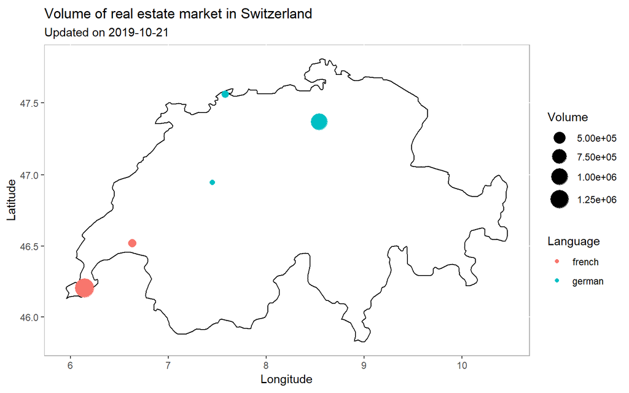

# Problem 3: 3-D Random Walk

## Question a :

We represent a random walk with the package plot 3D. In red is the departure point and in blue is the arrival point of the random walk. In this question we use 10000 iterations.

Last coordinates after random walk of 10 000 iterations

| x | y | z | iteration |
| --- | --- | --- | --- |
| 26 | -44 | 26 | 10000 |

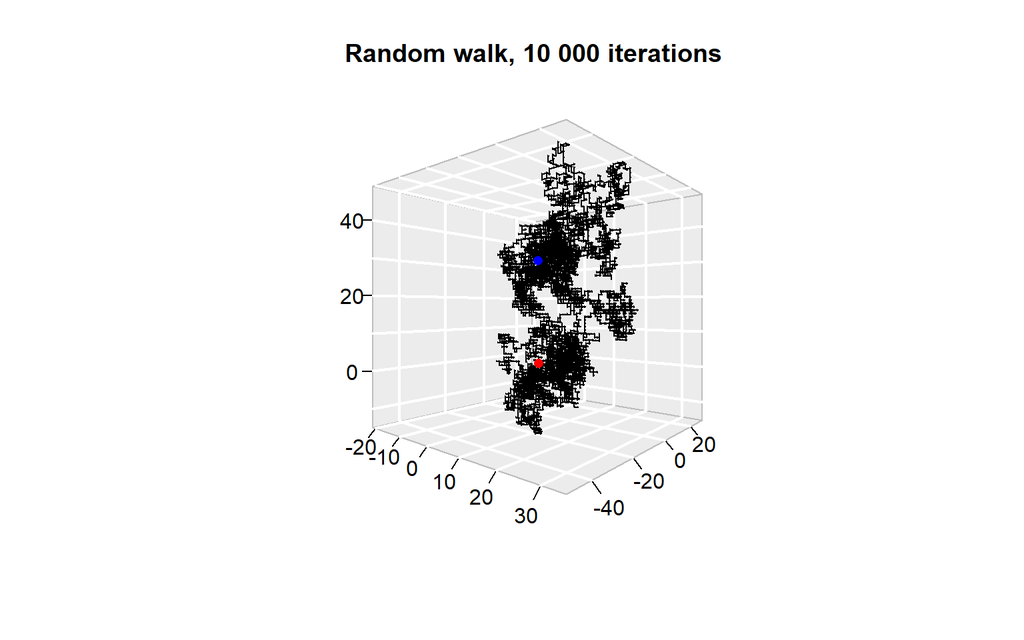

## Question b :

Last coordinates after random walk of 100 000 iterations

| x | y | z | iteration |
| --- | --- | --- | --- |
| 142 | -133 | -899 | 1e+05 |

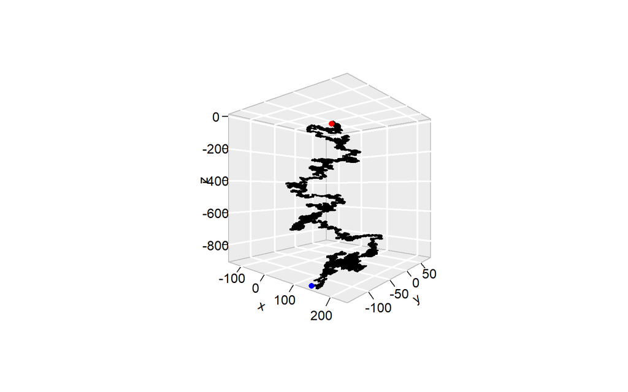

## Bonus :

This is a short video, which shows how a random walk evolve through time, in this case for the 100 first iterations.

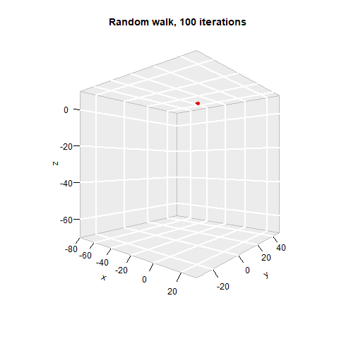

# Problem 4: Portfolio construction

## Data extraction

To construct the portfolio we need first to extract the stock data from internet.

We first extract the SP500 index tickers from Wikipedia.

| value |
| --- |
| MMM |
| ABT |
| ABBV |
| ABMD |
| ACN |
| ATVI |

Here are the first 6 extracted tickers. We can notice that there is 504 and not 500. This is because there is more than 500 companies listed on the SP500.

We then use those tickers to extract stocks price data from Yahoo. For our model only the daily change in percentage is relevant. So we will exctract only those.

| MMM | ABT | ABBV | ABMD | ACN | ATVI |
| --- | --- | --- | --- | --- | --- |
| -0.0294273 | -0.0054442 | 0.0070353 | -0.0289786 | -0.0045769 | -0.0090169 |
| 0.0016844 | -0.0057228 | -0.0086109 | -0.0855948 | 0.0015616 | -0.0137595 |
| -0.0045042 | 0.0082583 | 0.0072107 | -0.0736125 | 0.0000866 | -0.0162016 |
| 0.0000604 | -0.0186150 | -0.0628051 | 0.0175184 | 0.0018188 | -0.0091492 |
| -0.0028353 | -0.0075872 | -0.0315972 | -0.0013317 | 0.0049278 | -0.0034627 |
| -0.0063521 | -0.0048421 | 0.0120115 | 0.0072388 | -0.0008603 | -0.0132036 |

Here are few columns of the extracted data. We can notice that each column is a particular stock and each row is a particular day. The dataframe is only composed of 498 instead of 504 because some tickers were deleted due to the fact that after scrapping they contained some NA entries. This is because some companies were listed on the SP500 less than 3 years ago.

## Data preparation for computation

| Company.1 | Company.2 | mean.return.company.1 | mean.return.company.2 | sd.return.company.1 | sd.return.company.2 | Cov |
| --- | --- | --- | --- | --- | --- | --- |
| ABT | MMM | 0.0010310 | 2.22e-05 | 0.0122903 | 0.013114 | 7.38e-05 |
| ABBV | MMM | 0.0004619 | 2.22e-05 | 0.0179858 | 0.013114 | 7.80e-05 |
| ABMD | MMM | 0.0007779 | 2.22e-05 | 0.0253620 | 0.013114 | 9.19e-05 |
| ACN | MMM | 0.0007091 | 2.22e-05 | 0.0118219 | 0.013114 | 7.99e-05 |
| ATVI | MMM | 0.0004855 | 2.22e-05 | 0.0220643 | 0.013114 | 8.35e-05 |
| ADBE | MMM | 0.0013156 | 2.22e-05 | 0.0174408 | 0.013114 | 9.24e-05 |

The data after preparation have 7 columns: a pair of tickers, their daily return, their standard deviation and the covariance. The data frame have 123753 which is the expected number if we combine all the possible pairs of tickers following this equation :
$$\frac{n(n-1)}{2}$$

Now, to find the expected return and covariance we will use two functions :

$$Portfolio\; expected \;return: \;\;\;\;\;\; \mathbb{E}(R_p)= w\mathbb{E}(R_{i}) + (1-w)\mathbb{E}(R_{j})$$
$$Portfolio \;return \; variance: \;\;\;\;\;\; \sigma^2_p = w^2\sigma^2_i + (1-w)^2\sigma^2_j + 2w(1-w)\sigma_i\sigma_j\rho_{ij}$$

To facilitate calculations the weight will not be continuous but distributed between 0 and 1 in sequences of 0.1.

## Data processing

For the heavy calculation of running the function 11 times over all the 123753 rows the package future was used to distribute the calculation amongst different cores.

## Result

| company.1 | company.2 | Weight.Company.1 | Return | SD |
| --- | --- | --- | --- | --- |
| USB | DUK | 0.4 | 0.0003279 | 0.0068968 |

The less risky portfolio

Here is finally the portfolio with the smaller SD. Now we will plot it against all the other portfolios with the same weight.

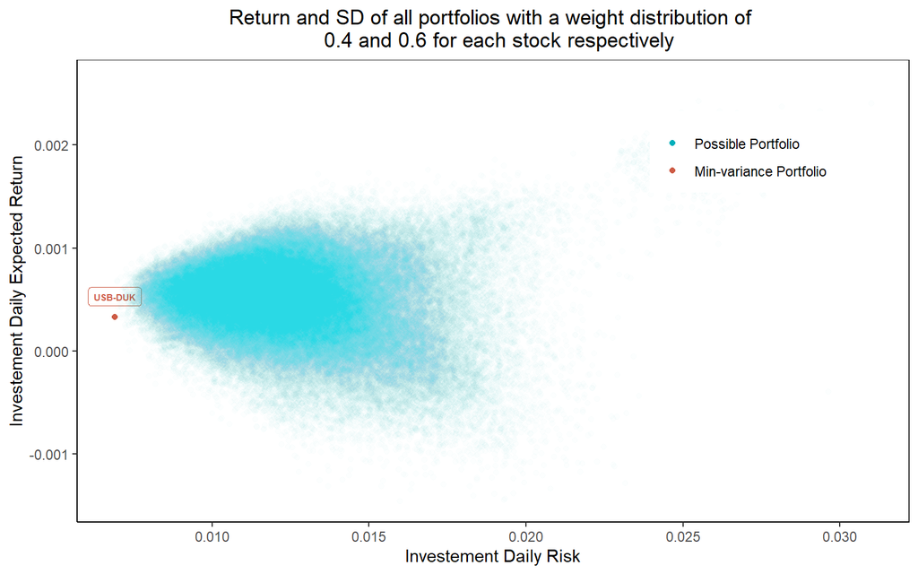

With one milion invested in this portfolio the daily expected return would be 300$.

Rita Sefraoui Tahiri, Simon Fornerod, David Pitteloud, Leonard Philippossian, Alexandre Schroeter

21 octobre, 2019